# Assignment 6

In this assignment, you'll analyze a collection of data sets from the [San Francisco Open Data Portal](http://data.sfgov.org/) and [Zillow](https://www.zillow.com/). The data sets have been stored in the SQLite database `sf_data.sqlite`, which you can [download here](http://anson.ucdavis.edu/~nulle/sf_data.sqlite). The database contains the following tables:

| Table | Description |
| --- | --- |
| `crime` | Crime reports dating back to 2010. |
| `mobile_food_locations` | List of all locations where mobile food vendors sell. |
| `mobile_food_permits` | List of all mobile food vendor permits. More details [here](https://data.sfgov.org/api/views/rqzj-sfat/files/8g2f5RV4PEk0_b24iJEtgEet9gnh_eA27GlqoOjjK4k?download=true&filename=DPW_DataDictionary_Mobil… |
| `mobile_food_schedule` | Schedules for mobile food vendors. |
| `noise` | Noise complaints dating back to August 2015. |
| `parking` | List of all parking lots. |
| `parks` | List of all parks. |
| `schools` | List of all schools. |
| `zillow` | Zillow rent and housing statistics dating back to 1996. More details [here](https://www.zillow.com/research/data/). |

The `mobile_food_` tables are explicitly connected through the `locationid` and `permit` columns. The other tables are not connected, but you may be able to connect them using dates, latitude/longitude, or postal codes.

Shapefiles for US postal codes are available [here](https://www.census.gov/geo/maps-data/data/cbf/cbf_zcta.html). These may be useful for converting latitude/longitude to postal codes.

Shapefiles for San Francisco Neighborhoods are available [here](https://data.sfgov.org/Geographic-Locations-and-Boundaries/SF-Find-Neighborhoods/pty2-tcw4).

```python
import pandas as pd
import numpy as np
from matplotlib import pyplot as plt
import sqlalchemy as sqla
import sqlite3
%matplotlib inline
plt.style.use('ggplot')
import matplotlib.cm
from mpl_toolkits.basemap import Basemap
from matplotlib.patches import Polygon
from matplotlib.collections import PatchCollection
from matplotlib.colors import Normalize
from datetime import datetime
```

```python
sqlite_file = 'sf_data.sqlite'
sf_conn = sqla.create_engine('sqlite:///'+ sqlite_file)
```

**Exercise 1.1.** Which mobile food vendor(s) sells at the most locations?

```python
vendors = pd.read_sql_query("Select DISTINCT s.locationid, s.permit, p.Applicant from  mobile_food_schedule s "
                  "LEFT JOIN mobile_food_permits p ON p.permit = s.permit;",sf_conn)
```

```python
items_counts = vendors['Applicant'].value_counts()
```

```python
items_counts
```

```
May Catering                                                               58
Natan's Catering                                                           37
Anas Goodies Catering                                                      37
Liang Bai Ping                                                             33
Park's Catering                                                            23
Singh Brothers Ice Cream                                                   21
Sun Rise Catering                                                          19
Mang Hang Catering                                                         19
John's Catering #5                                                         19
Two G's Catering                                                           17
D & T Catering                                                             17
Steve's Mobile Deli                                                        16
Mini Mobile Food Catering                                                  15
Quan Catering                                                              15
Mike's Catering                                                            13
M M Catering                                                               13
F & C Catering                                                             13
Bach Catering                                                              11
Munch A Bunch                                                              10
Eva's Catering                                                              8
Off the Grid Services, LLC                                                  8
Halal Cart, LLC                                                             7
Roadside Rotisserie Corporation / Country Grill                             7
BH & MT LLC                                                                 7
Linda's Catering                                                            7
San Francisco Carts & Concessions, Inc. DBA Stanley's Steamers Hot Dogs     6
Tacos Rodriguez                                                             6
Philz Coffee Truck                                                          5
Cheese Gone Wild                                                            5
Casey's Pizza, LLC                                                          5
                                                                           ..
Sausage Slinger                                                             1
Kabob Trolley, LLC                                                          1
Fruteria Serrano                                                            1
Faith Sandwich                                                              1
French Creme Brulee                                                         1
El Tonayanse #4 / #36                                                       1
Betty McGee Creole                                                          1
Ruru Soul                                                                   1
Breaking Bread Inc.                                                         1
A Taste of Chicago                                                          1
Tacos El Ojo De Agua                                                        1
Leo's Hot Dogs                                                              1
Rita's Catering                                                             1
Golden Gate Halal Food                                                      1
Got Snacks                                                                  1
SF Cart Project                                                             1
The Huge Hotdog Concession                                                  1
Curbside Coffee                                                             1
The Creme Brulee Cart                                                       1
Missing Link SF                                                             1
Peruchi Food Truck,LLC                                                      1
El Gallo Jiro                                                               1
Geary Cocina                                                                1
BHUK Burger                                                                 1
Stanley Roth                                                                1
Wexler, LLC                                                                 1
Buenafe                                                                     1
Munch India                                                                 1
Mob Dog                                                                     1
Mario's Colombian and Mexican Food                                          1
Name: Applicant, dtype: int64
```

We find that **May Catering** sells at the most locations (58)! our initial SQL argument searched for the distinct location IDs in the mobile_food_schedule (since it duplicates itself for times) and also took the permit values and joined it with the permits from mobile_food_permits and the names of the places. I then put that into a pandas data frame and then took the count of them all

**Exercise 1.2.** Ask and use the database to analyze 5 questions about San Francisco. For each question, write at least 150 words and support your answer with plots. Make a map for at least 2 of the 5 questions.

You should try to come up with some questions on your own, but these are examples of reasonable questions:

- Which parts of the city are the most and least expensive?
- Which parts of the city are the most dangerous (and at what times)?
- Are noise complaints and mobile food vendors related?
- What are the best times and places to find food trucks?
- Is there a relationship between housing prices and any of the other tables?

Please make sure to clearly state each of your questions in your submission.

# What are the Rental Prices in each zip code?

```python
regionprice = pd.read_sql_query("Select RegionName, AVG(ZriPerSqft_AllHomes) From zillow GROUP BY RegionName",
                                sf_conn)
regionprice = regionprice.dropna()
regionprice['RegionName']=regionprice['RegionName'].astype(str)
regionprice
```

|  | RegionName | AVG(ZriPerSqft_AllHomes) |
| --- | --- | --- |
| 0 | 94080 | 2.172000 |
| 1 | 94102 | 3.984933 |
| 2 | 94103 | 3.679040 |
| 4 | 94105 | 4.279173 |
| 5 | 94107 | 3.665093 |
| 6 | 94108 | 4.149920 |
| 7 | 94109 | 3.852080 |
| 8 | 94110 | 3.145520 |
| 9 | 94111 | 3.669520 |
| 10 | 94112 | 2.466640 |
| 11 | 94114 | 3.359920 |
| 12 | 94115 | 3.606293 |
| 13 | 94116 | 2.441573 |
| 14 | 94117 | 3.114373 |
| 15 | 94118 | 2.868667 |
| 16 | 94121 | 2.402933 |
| 17 | 94122 | 2.386080 |
| 18 | 94123 | 3.764773 |
| 19 | 94124 | 2.328160 |
| 20 | 94127 | 2.457733 |
| 21 | 94131 | 3.044160 |
| 22 | 94132 | 2.370480 |
| 23 | 94133 | 3.898693 |
| 24 | 94134 | 2.395173 |
| 25 | 94158 | 3.720693 |

```python
m = Basemap(resolution='c', # c, l, i, h, f or None
            projection='merc',
            lat_0=37.69987, lon_0=-122.436063,
            llcrnrlon=-122.520218, llcrnrlat= 37.629569, urcrnrlon=-122.35199, urcrnrlat=37.8321)
```

```
(33144,
 5,
 [-176.684659, -14.37374, 0.0, 0.0],
 [145.830418, 71.341324, 0.0, 0.0],
```

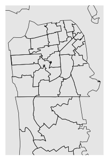

```python
m.readshapefile('cb_2015_us_zcta510_500k/cb_2015_us_zcta510_500k', 'zips')
```

```python
m.zips_info[0]
```

```
{'AFFGEOID10': '8600000US36907',
 'ALAND10': 322847900,
 'AWATER10': 352811,
 'GEOID10': '36907',
 'RINGNUM': 1,
 'SHAPENUM': 1,
 'ZCTA5CE10': '36907'}
```

```python
df_poly = pd.DataFrame({
        'shapes': [Polygon(np.array(shape), True) for shape in m.zips],
        'RegionName': [zips['ZCTA5CE10'] for zips in m.zips_info]
    })
df_poly = pd.merge(regionprice,df_poly, on='RegionName', how='right')
```

```python
df_poly = df_poly.dropna()
```

|  | RegionName | AVG(ZriPerSqft_AllHomes) | shapes |
| --- | --- | --- | --- |
| 0 | 94080 | 2.172000 | Poly((5694.18, 2925.69) ...) |
| 1 | 94102 | 3.984933 | Poly((10039.7, 20848.1) ...) |
| 2 | 94103 | 3.679040 | Poly((10430.1, 19142.4) ...) |
| 3 | 94105 | 4.279173 | Poly((12983.3, 22236.3) ...) |
| 4 | 94107 | 3.665093 | Poly((12801.6, 18979.8) ...) |
| 5 | 94108 | 4.149920 | Poly((11719.1, 23251.1) ...) |
| 6 | 94109 | 3.852080 | Poly((9746.56, 25149.8) ...) |
| 7 | 94110 | 3.145520 | Poly((10396.3, 15006.2) ...) |
| 8 | 94111 | 3.669520 | Poly((12738.4, 24895.6) ...) |
| 9 | 94112 | 2.466640 | Poly((6029.43, 11320.4) ...) |
| 10 | 94114 | 3.359920 | Poly((7362.88, 18158) ...) |
| 11 | 94115 | 3.606293 | Poly((8219.3, 22813.6) ...) |
| 12 | 94116 | 2.441573 | Poly((1103.16, 18901.8) ...) |
| 13 | 94117 | 3.114373 | Poly((4772.6, 19182.5) ...) |
| 14 | 94118 | 2.868667 | Poly((4622.59, 20049.2) ...) |
| 15 | 94121 | 2.402933 | Poly((637.703, 21258.9) ...) |
| 16 | 94122 | 2.386080 | Poly((1150.64, 18904.2) ...) |
| 17 | 94123 | 3.764773 | Poly((7780.08, 24450.3) ...) |
| 18 | 94123 | 3.764773 | Poly((7490.09, 24502.3) ...) |
| 19 | 94124 | 2.328160 | Poly((12505.6, 15598.5) ...) |
| 20 | 94127 | 2.457733 | Poly((5409.52, 14772.1) ...) |
| 21 | 94131 | 3.044160 | Poly((6332.77, 18147.2) ...) |
| 22 | 94132 | 2.370480 | Poly((1348.83, 14841.1) ...) |
| 23 | 94133 | 3.898693 | Poly((11230, 25146) ...) |
| 24 | 94134 | 2.395173 | Poly((10039.9, 11520) ...) |
| 25 | 94158 | 3.720693 | Poly((13604.9, 20062.3) ...) |

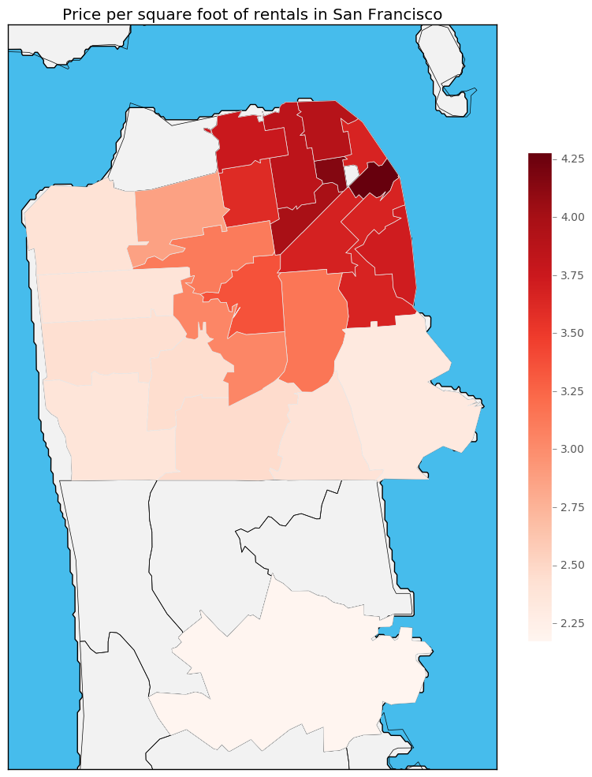

```python
fig, ax = plt.subplots(figsize=(10,20))

m = Basemap(resolution='f', # c, l, i, h, f or None
            projection='merc',
            lat_0=37.69987, lon_0=-122.436063,
            llcrnrlon=-122.520218, llcrnrlat= 37.629569, urcrnrlon=-122.35199, urcrnrlat=37.8321)

m.drawmapboundary(fill_color='#46bcec')
m.fillcontinents(color='#f2f2f2',lake_color='#46bcec')
m.drawcoastlines()
m.readshapefile('cb_2015_us_zcta510_500k/cb_2015_us_zcta510_500k', 'zips')


cmap = plt.get_cmap('Reds')
pc = PatchCollection(df_poly.shapes, zorder=2)
norm = Normalize()

pc.set_facecolor(cmap(norm(df_poly['AVG(ZriPerSqft_AllHomes)'].fillna(0).values)))
ax.add_collection(pc)

mapper = matplotlib.cm.ScalarMappable(norm=norm, cmap=cmap)

mapper.set_array(df_poly['AVG(ZriPerSqft_AllHomes)'])
plt.colorbar(mapper, shrink=0.4)
plt.title('Price per square foot of rentals in San Francisco')

m
```

Above we see a mapping done of the Zillow Rent Index per square foot in San Francisco (plus South San Francisco) with it organized per zip code area. First, the zillow data was taken from multiple days so I took the average of price per square foot of all homes in order to get an overall average. This data is from 2010 to 2017 measured monthly since this is a metric made by Zillow in order to measure the median rent in a region. How this metric is measured can be found online but it involves machine learning methods and other methods to find out the estimated rent. I believe it is fine to not include sold homes since San Francisco is very much a place where people rent instead of buy a home today. We also see that prices are very high in the waterfront areas near downtown and on the Embarcadero and decrease as you get further from the city center. This makes sense as it becomes more of a hassle to travel into the city for employment if you live on the outskirts of the city rather than the inner parts. I am somewhat surprised that the zip code near Golden Gate Park is not higher though since it is near an important place there.

# How has home turnover in SF changed over time?

```python
turnover = pd.read_sql_query("Select Date, AVG(Turnover_AllHomes) from zillow GROUP BY Date",sf_conn)
turnover = turnover.dropna()
turnover.index = range(len(turnover))
turnover
```

|  | Date | AVG(Turnover_AllHomes) |
| --- | --- | --- |
| 0 | 1998-01-01 00:00:00 | 5.943083 |
| 1 | 1998-02-01 00:00:00 | 6.000775 |
| 2 | 1998-03-01 00:00:00 | 6.063725 |
| 3 | 1998-04-01 00:00:00 | 6.094408 |
| 4 | 1998-05-01 00:00:00 | 6.080600 |
| 5 | 1998-06-01 00:00:00 | 6.064712 |
| 6 | 1998-07-01 00:00:00 | 6.146571 |
| 7 | 1998-08-01 00:00:00 | 6.125383 |
| 8 | 1998-09-01 00:00:00 | 6.118079 |
| 9 | 1998-10-01 00:00:00 | 6.134646 |
| 10 | 1998-11-01 00:00:00 | 6.083292 |
| 11 | 1998-12-01 00:00:00 | 6.117133 |
| 12 | 1999-01-01 00:00:00 | 6.113500 |
| 13 | 1999-02-01 00:00:00 | 6.163229 |
| 14 | 1999-03-01 00:00:00 | 6.190900 |
| 15 | 1999-04-01 00:00:00 | 6.231987 |
| 16 | 1999-05-01 00:00:00 | 6.255812 |
| 17 | 1999-06-01 00:00:00 | 6.284588 |
| 18 | 1999-07-01 00:00:00 | 6.327400 |
| 19 | 1999-08-01 00:00:00 | 6.314725 |
| 20 | 1999-09-01 00:00:00 | 6.226287 |
| 21 | 1999-10-01 00:00:00 | 6.219621 |
| 22 | 1999-11-01 00:00:00 | 6.278079 |
| 23 | 1999-12-01 00:00:00 | 6.204104 |
| 24 | 2000-01-01 00:00:00 | 6.183975 |
| 25 | 2000-02-01 00:00:00 | 6.116542 |
| 26 | 2000-03-01 00:00:00 | 6.065404 |
| 27 | 2000-04-01 00:00:00 | 5.899837 |
| 28 | 2000-05-01 00:00:00 | 5.808804 |
| 29 | 2000-06-01 00:00:00 | 5.743875 |
| ... | ... | ... |
| 199 | 2014-08-01 00:00:00 | 5.381815 |
| 200 | 2014-09-01 00:00:00 | 5.448169 |
| 201 | 2014-10-01 00:00:00 | 5.511427 |
| 202 | 2014-11-01 00:00:00 | 5.436958 |
| 203 | 2014-12-01 00:00:00 | 5.309450 |
| 204 | 2015-01-01 00:00:00 | 5.177500 |
| 205 | 2015-02-01 00:00:00 | 5.047508 |
| 206 | 2015-03-01 00:00:00 | 5.041258 |
| 207 | 2015-04-01 00:00:00 | 5.026896 |
| 208 | 2015-05-01 00:00:00 | 4.982765 |
| 209 | 2015-06-01 00:00:00 | 4.978212 |
| 210 | 2015-07-01 00:00:00 | 4.956696 |
| 211 | 2015-08-01 00:00:00 | 4.827927 |
| 212 | 2015-09-01 00:00:00 | 4.748104 |
| 213 | 2015-10-01 00:00:00 | 4.655288 |
| 214 | 2015-11-01 00:00:00 | 4.630704 |
| 215 | 2015-12-01 00:00:00 | 4.612950 |
| 216 | 2016-01-01 00:00:00 | 4.583546 |
| 217 | 2016-02-01 00:00:00 | 4.469888 |
| 218 | 2016-03-01 00:00:00 | 4.350200 |
| 219 | 2016-04-01 00:00:00 | 4.245008 |
| 220 | 2016-05-01 00:00:00 | 4.142031 |
| 221 | 2016-06-01 00:00:00 | 3.982708 |
| 222 | 2016-07-01 00:00:00 | 3.860835 |
| 223 | 2016-08-01 00:00:00 | 3.804935 |
| 224 | 2016-09-01 00:00:00 | 3.650581 |
| 225 | 2016-10-01 00:00:00 | 3.535650 |
| 226 | 2016-11-01 00:00:00 | 3.489904 |
| 227 | 2016-12-01 00:00:00 | 3.449150 |
| 228 | 2017-01-01 00:00:00 | 3.404942 |

229 rows × 2 columns

```python
for x in xrange(len(turnover['Date'])):
    turnover['Date'][x] = datetime.strptime(turnover['Date'][x],'%Y-%m-%d %H:%M:%S')
print 'done'
#runs forever for some reason oh well?
```

```
---------------------------------------------------------------------------
TypeError                                 Traceback (most recent call last)
<ipython-input-204-d319fc76e2e7> in <module>()
      1 for x in xrange(len(turnover['Date'])):
----> 2     turnover['Date'][x] = datetime.strptime(turnover['Date'][x],'%Y-%m-%d %H:%M:%S')
      3 print 'done'

TypeError: strptime() argument 1 must be string, not datetime.datetime
```

```python
datedf = turnover.set_index(['Date'])
datedf = datedf.rename(columns={"AVG(Turnover_AllHomes)":'% of all homes sold in past month'})
```

```python
datedf
```

| Date | % of all homes sold in past month |
| --- | --- |
| 1998-01-01 | 5.943083 |
| 1998-02-01 | 6.000775 |
| 1998-03-01 | 6.063725 |
| 1998-04-01 | 6.094408 |
| 1998-05-01 | 6.080600 |
| 1998-06-01 | 6.064712 |
| 1998-07-01 | 6.146571 |
| 1998-08-01 | 6.125383 |
| 1998-09-01 | 6.118079 |
| 1998-10-01 | 6.134646 |
| 1998-11-01 | 6.083292 |
| 1998-12-01 | 6.117133 |
| 1999-01-01 | 6.113500 |
| 1999-02-01 | 6.163229 |
| 1999-03-01 | 6.190900 |
| 1999-04-01 | 6.231987 |
| 1999-05-01 | 6.255812 |
| 1999-06-01 | 6.284588 |
| 1999-07-01 | 6.327400 |
| 1999-08-01 | 6.314725 |
| 1999-09-01 | 6.226287 |
| 1999-10-01 | 6.219621 |
| 1999-11-01 | 6.278079 |
| 1999-12-01 | 6.204104 |
| 2000-01-01 | 6.183975 |
| 2000-02-01 | 6.116542 |
| 2000-03-01 | 6.065404 |
| 2000-04-01 | 5.899837 |
| 2000-05-01 | 5.808804 |
| 2000-06-01 | 5.743875 |
| ... | ... |
| 2014-08-01 | 5.381815 |
| 2014-09-01 | 5.448169 |
| 2014-10-01 | 5.511427 |
| 2014-11-01 | 5.436958 |
| 2014-12-01 | 5.309450 |
| 2015-01-01 | 5.177500 |
| 2015-02-01 | 5.047508 |
| 2015-03-01 | 5.041258 |
| 2015-04-01 | 5.026896 |
| 2015-05-01 | 4.982765 |
| 2015-06-01 | 4.978212 |
| 2015-07-01 | 4.956696 |
| 2015-08-01 | 4.827927 |
| 2015-09-01 | 4.748104 |
| 2015-10-01 | 4.655288 |
| 2015-11-01 | 4.630704 |
| 2015-12-01 | 4.612950 |
| 2016-01-01 | 4.583546 |
| 2016-02-01 | 4.469888 |
| 2016-03-01 | 4.350200 |
| 2016-04-01 | 4.245008 |
| 2016-05-01 | 4.142031 |
| 2016-06-01 | 3.982708 |
| 2016-07-01 | 3.860835 |
| 2016-08-01 | 3.804935 |
| 2016-09-01 | 3.650581 |
| 2016-10-01 | 3.535650 |
| 2016-11-01 | 3.489904 |
| 2016-12-01 | 3.449150 |
| 2017-01-01 | 3.404942 |

229 rows × 1 columns

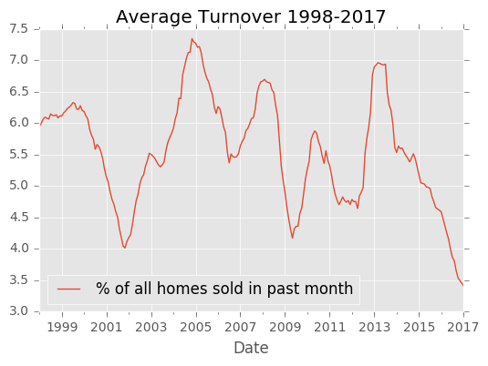

```python
datedf.plot()
plt.title('Average Turnover 1998-2017')
```

### Analysis

In the above metric we see the overall turnover rate of homes from 1998 to 2017 in San Francisco. I took an average of the turnover so some places may be higher than others. In this we see that there are some specific dips and rises that should be paid attention to in order to make assumptions about the health of the San Franciso Housing market. First, Turnover is the percentage of all homes in an area sold in the past month. If this is high then it means lots of people are selling their homes and lots of people are purchasing them as well. When it is low, this could be a supply or a demand issue, either nobody wants to buy the houses (low demand) or nobody wants to sell the houses (low supply). In San Franciso though there is the common knowldege that housing prices are one of the highest in the country meaning that the main issue in at least today is that nobody wants to sell or that supply is low.  
First though, lets look at some history, we see dips primary in 2001 and 2008 which were obviously demand issues with 2001 being the burst of the .com bubble and 2008 being the Great Recession, both times people could not afford to buy a home. This soon peaked in 2013 with the tech industry reviving and then plummets as housing that was purchased is more than likely rented out by holding companies instead of lived in by individuals, becoming the supply issue. This shows that there needs to be more housing built in San Francisco in order to help alleviate this immedately.

# Are schools near parks?

```python
schoolloc = pd.read_sql_query('SELECT Lat, Lon from schools;', sf_conn)
parkloc = pd.read_sql_query('SELECT Lat, Lon from parks;', sf_conn)
```

```python
schoollat = list(schoolloc['Lat'])
schoollon = list(schoolloc['Lon'])
parklat = list(parkloc['Lat'])
parklon = list(parkloc['Lon'])
```

```python
schoolx,schooly = m(schoollon,schoollat)
parkx,parky = m(parklon,parklat)
```

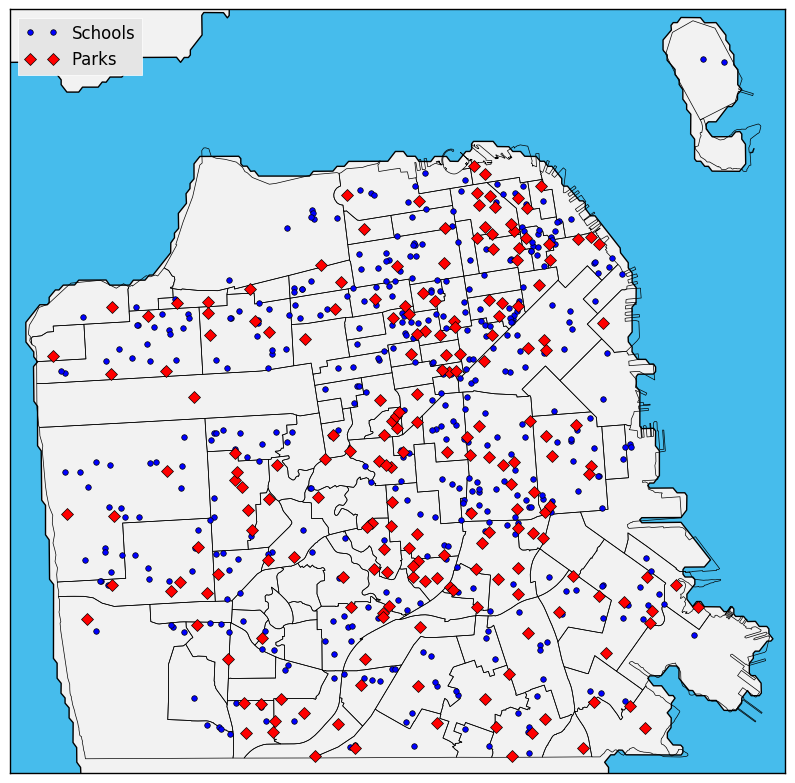

```python
fig, ax = plt.subplots(figsize=(10,20))

m = Basemap(resolution='f', # c, l, i, h, f or None
            projection='merc',
            lat_0=37.770052, lon_0=-122.436174,
            llcrnrlon=-122.51884406045, llcrnrlat= 37.705689, urcrnrlon=-122.353706, urcrnrlat=37.834327)

m.drawmapboundary(fill_color='#46bcec')
m.fillcontinents(color='#f2f2f2',lake_color='#46bcec')
m.drawcoastlines()
m.readshapefile('geo_export_bef1d093-7abc-4f75-a326-8b4e514beedf','sfhood')

m.plot(schoolx,schooly,'bo',markersize = 4, label = 'Schools')
m.plot(parkx,parky, 'rD',markersize = 6, label = 'Parks')
plt.legend(loc= 'upper left')
m
```

From this map we can see where the parks and schools in San Francisco are. One of the more surprising results was the density of some of the parks and school as you get closer to the city center with many being very close to each other while as you get further from the city center, there is more distance between the schools. Another surprise is that some neighborhoods have only one or two schools or parks which makes some sense due to the fact that SF has significantly less children since the tech boom restarted back up due to rising housing prices again. This only shows where schools are and not the enrollment however, meaning that some of these may be very small private or charter schools for the wealthy elite and not classic public schools. Another surprise is that there are 2 schools on Treasure island. I did not even know schools were there really.

# Are food trucks where the noise complaints are?

```python
foodloc = pd.read_sql_query('SELECT Latitude, Longitude FROM mobile_food_locations', sf_conn)
noises = pd.read_sql_query('Select Neighborhood, COUNT(*) from noise Group By Neighborhood;', sf_conn)
```

```python
noises = noises.dropna()
noises.index = range(len(noises))
```

```python
foodlat = list(foodloc['Latitude'])
foodlon = list(foodloc['Longitude'])
foodx,foody = m(foodlon,foodlat)
```

```python
m.sfhood_info[0]
```

```
{'RINGNUM': 1,
 'SHAPENUM': 1,
 'link': 'http://en.wikipedia.org/wiki/Sea_Cliff,_San_Francisco,_California',
 'name': 'Seacliff'}
```

```python
df_poly = pd.DataFrame({
        'shapes': [Polygon(np.array(shape), True) for shape in m.sfhood],
        'Neighborhood': [hood['name'] for hood in m.sfhood_info]
    })
df_poly = pd.merge(noises,df_poly, on='Neighborhood', how='right')
```

```python
df_poly
```

|  | Neighborhood | COUNT(*) | shapes |
| --- | --- | --- | --- |
| 0 | Alamo Square | 22.0 | Poly((9682.94, 10256.9) ...) |
| 1 | Anza Vista | 8.0 | Poly((8119.23, 10802.9) ...) |
| 2 | Aquatic Park / Ft. Mason | 9.0 | Poly((10422.8, 13846.9) ...) |
| 3 | Ashbury Heights | 11.0 | Poly((7437.41, 7843.91) ...) |
| 4 | Balboa Terrace | 1.0 | Poly((5263.58, 3871.36) ...) |
| 5 | Bayview | 48.0 | Poly((12997.4, 3130.22) ...) |
| 6 | Bernal Heights | 76.0 | Poly((11237.9, 4708.61) ...) |
| 7 | Bret Harte | 22.0 | Poly((13701.6, 2353.37) ...) |
| 8 | Buena Vista | 24.0 | Poly((8240.93, 8680.5) ...) |
| 9 | Candlestick Point SRA | 1.0 | Poly((13787.1, 380.602) ...) |
| 10 | Castro | 38.0 | Poly((9764.98, 8461.36) ...) |
| 11 | Cathedral Hill | 40.0 | Poly((10753.5, 11773.6) ...) |
| 12 | Cayuga | 10.0 | Poly((8354.96, 1110.73) ...) |
| 13 | Central Waterfront | 16.0 | Poly((14558.4, 8251.97) ...) |
| 14 | Chinatown | 47.0 | Poly((12153.9, 12398.3) ...) |
| 15 | Civic Center | 121.0 | Poly((11823.6, 10516.7) ...) |
| 16 | Clarendon Heights | 5.0 | Poly((8051.67, 7777.6) ...) |
| 17 | Cole Valley | 11.0 | Poly((7282.35, 8795.86) ...) |
| 18 | Corona Heights | 17.0 | Poly((9302.13, 8011.64) ...) |
| 19 | Cow Hollow | 16.0 | Poly((8003.79, 12516.4) ...) |
| 20 | Crocker Amazon | 21.0 | Poly((7179.07, 360.783) ...) |
| 21 | Diamond Heights | 7.0 | Poly((8962.08, 6041.79) ...) |
| 22 | Dogpatch | 42.0 | Poly((14558.4, 8251.97) ...) |
| 23 | Dolores Heights | 60.0 | Poly((9568.38, 7779.65) ...) |
| 24 | Downtown / Union Square | 61.0 | Poly((12950.2, 11992.6) ...) |
| 25 | Duboce Triangle | 30.0 | Poly((9117.44, 9090.82) ...) |
| 26 | Eureka Valley | 25.0 | Poly((9062.57, 7967.2) ...) |
| 27 | Excelsior | 36.0 | Poly((9758.99, 1519.46) ...) |
| 28 | Fairmount | 8.0 | Poly((9260.87, 5267.94) ...) |
| 29 | Financial District | 62.0 | Poly((12886, 12388.2) ...) |
| ... | ... | ... | ... |
| 87 | Seacliff | 8.0 | Poly((2823.1, 10944.3) ...) |
| 88 | Sherwood Forest | 2.0 | Poly((6664.95, 4898.65) ...) |
| 89 | Showplace Square | 23.0 | Poly((12686.8, 9644.81) ...) |
| 90 | Silver Terrace | 13.0 | Poly((13229.6, 3458.42) ...) |
| 91 | South Beach | 39.0 | Poly((14936.1, 11489.1) ...) |
| 92 | South of Market | 480.0 | Poly((13680.4, 12018.5) ...) |
| 93 | St. Francis Wood | 1.0 | Poly((5256.71, 4079.14) ...) |
| 94 | Stonestown | 9.0 | Poly((5231.34, 3562.52) ...) |
| 95 | Sunnydale | 1.0 | Poly((10572.3, 372.836) ...) |
| 96 | Sunnyside | 6.0 | Poly((7779.86, 3953.02) ...) |
| 97 | Sutro Heights | 14.0 | Poly((1750.13, 10631.8) ...) |
| 98 | Telegraph Hill | 13.0 | Poly((12267.3, 14009.4) ...) |
| 99 | Tenderloin | 116.0 | Poly((12116.9, 11455.2) ...) |
| 100 | Treasure Island | 3.0 | Poly((16354.4, 15474.6) ...) |
| 101 | Union Street | 45.0 | Poly((9023.39, 13212) ...) |
| 102 | University Mound | 3.0 | Poly((10785.6, 2601.81) ...) |
| 103 | Upper Market | 9.0 | Poly((8297.93, 7014.89) ...) |
| 104 | Visitacion Valley | 14.0 | Poly((11411, 370.944) ...) |
| 105 | West Portal | 6.0 | Poly((4863.84, 4067.72) ...) |
| 106 | Western Addition | 49.0 | Poly((8824.83, 10914.8) ...) |
| 107 | Westwood Highlands | 2.0 | Poly((6598.25, 4020.62) ...) |
| 108 | Westwood Park | 6.0 | Poly((6479.41, 3478.53) ...) |
| 109 | Yerba Buena Island | NaN | Poly((16433.5, 15508.3) ...) |
| 110 | Mt. Davidson Manor | NaN | Poly((6125.57, 3632.07) ...) |
| 111 | Monterey Heights | NaN | Poly((6194.5, 4404.85) ...) |
| 112 | McLaren Park | NaN | Poly((10550.6, 655.194) ...) |
| 113 | Apparel City | NaN | Poly((12631.9, 5252.44) ...) |
| 114 | St. Marys Park | NaN | Poly((10468.1, 4172.37) ...) |
| 115 | Fishermans Wharf | NaN | Poly((10971.1, 13937.6) ...) |
| 116 | Forest Knolls | NaN | Poly((7201.69, 7217.86) ...) |

117 rows × 3 columns

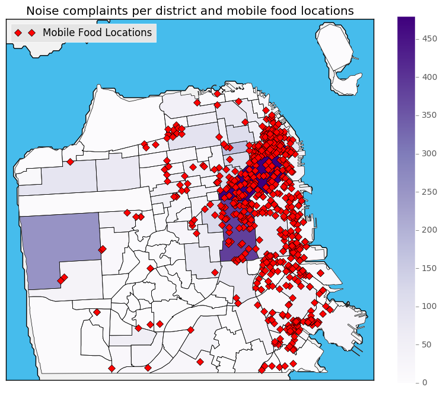

```python
fig, ax = plt.subplots(figsize=(10,20))

m = Basemap(resolution='f', # c, l, i, h, f or None
            projection='merc',
            lat_0=37.770052, lon_0=-122.436174,
            llcrnrlon=-122.51884406045, llcrnrlat= 37.705689, urcrnrlon=-122.353706, urcrnrlat=37.834327)

m.drawmapboundary(fill_color='#46bcec')
m.fillcontinents(color='#f2f2f2',lake_color='#46bcec')
m.drawcoastlines()

cmap = plt.get_cmap('Purples')
pc = PatchCollection(df_poly.shapes, zorder=2)
norm = Normalize()

pc.set_facecolor(cmap(norm(df_poly['COUNT(*)'].fillna(0).values)))
ax.add_collection(pc)

mapper = matplotlib.cm.ScalarMappable(norm=norm, cmap=cmap)

m.plot(foodx,foody, 'rD',markersize = 6, label = 'Mobile Food Locations')
plt.legend(loc= 'upper left')

m.readshapefile('geo_export_bef1d093-7abc-4f75-a326-8b4e514beedf','sfhood')

mapper.set_array(df_poly['COUNT(*)'])
plt.colorbar(mapper, shrink=0.4)
plt.title('Noise complaints per district and mobile food locations')

m
```

In this we see that the max is the South of Market Neighborhood for noise complaints which also has a large number of mobile food locations. However, it is rash to assume that they bring excess noise since we see in the South East part of town and along the Embarcadero there are a lot of mobile food locations but they too have low noise complaints in those neighborhoods. In fact, in the western district we see it is the 3rd noisiest (I believe it is the sunset district) but there are no mobile food locations inside its borders, only 4 along the edge, but it is a major residential part of San Francisco. It seems most Mobile food locations follow tourists which comes with traffic and other nuisances that could be the main reason for the noise complaints. As well, this map is only total number of noise complaints and does not control for population living in each district, normalized, this could be very different.

# Is there heavy crime near where food trucks are?

```python
crimeloc = pd.read_sql_query("SELECT date(Datetime),Category, Lon, Lat from crime WHERE Datetime > '2016-9-18' AND Category != 'NON-CRIMINAL' "
	"AND Category != 'RUNAWAY' AND Category != 'DRIVING UNDER THE INFLUENCE' "
	"AND Category != 'WARRANTS' AND Category != 'OTHER OFFENSES';", sf_conn)
```

```python
crimeloc = crimeloc.dropna()
```

```python
crimelat = list(crimeloc['Lat'])
crimelon = list(crimeloc['Lon'])
crimex, crimey = m(crimelon, crimelat)
```

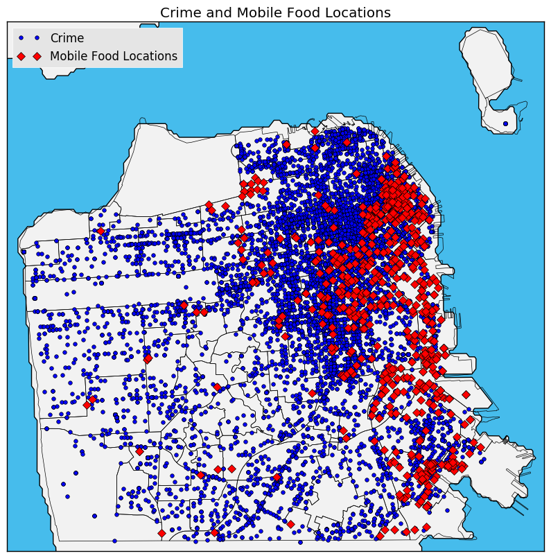

```python
fig, ax = plt.subplots(figsize=(10,20))

m = Basemap(resolution='f', # c, l, i, h, f or None
            projection='merc',
            lat_0=37.770052, lon_0=-122.436174,
            llcrnrlon=-122.51884406045, llcrnrlat= 37.705689, urcrnrlon=-122.353706, urcrnrlat=37.834327)

m.drawmapboundary(fill_color='#46bcec')
m.fillcontinents(color='#f2f2f2',lake_color='#46bcec')
m.drawcoastlines()
m.readshapefile('geo_export_bef1d093-7abc-4f75-a326-8b4e514beedf','sfhood')

m.plot(crimex, crimey, 'bo', markersize = 4, label = 'Crime')
m.plot(foodx,foody, 'rD',markersize = 6, label = 'Mobile Food Locations')

plt.legend(loc= 'upper left')
plt.title('Crime and Mobile Food Locations')
m
```

In this chart we see plotted locations of crimes as of 6 months ago (9/18/16), which surprisingly gave us only results from 2017. (crimes since 2010 made the map completely blue) I also went about filtering out non-criminal, runaways, warrants, Driving Under the Influence, and Other offences. This still gives us a ton of crimes which is fairly concerning if you are going to pay an arm and a leg to live in this city but alas. We see the relationship is fairly strong with most crimes being around the embarcadero and the City Center and tapering out as you get further from the City Center. However, this makes logical sense that places with foot traffic would have more crime and that the same places with more foot traffic would be a GREAT place to have a mobile food location. This relation makes it difficult to come to a distinct conclusion to this question but I will say that SF has a TON of crime. and that one sector that shows that mobile food locations have little relation is on the border of the one district without crime in the north where there is a bundle of mobile food locations with very little crime in the area surounding it.